# Week 2a

## What is reproducible research and why is it important?

### Dr. Nyssa Silbiger

### CSUN Spring 2022

### (updated: 2022-01-31)

# Outline of class

1. What is reproducible science?

1. Open science: Should data and protocols be public?

1. Tools for reproducible science:
  - Rstudio
  - Github

# Reproducibility - what is it?

### “U.S. National Science Foundation (NSF) subcommittee on replicability in science: ‘reproducibility refers to the **ability of a researcher to duplicate the results of a prior study using the same materials as were used by the original investigator.'**”

[figure not shown]

Goodman et al., Science Translational Medicine  01 Jun 2016:
Vol. 8, Issue 341, pp. 341ps12
DOI: 10.1126/scitranslmed.aaf5027

# We are in a reproducibility crisis in science

[figure not shown]

Monya Baker (2016). 1500 scientists lift the lid on reproducibility. Nature 533 (7604).

# Types of reproducibility

From Victoria Stodden (as summarized in the ROpenSci Reproducibility Guide)

“**Computational reproducibility**: when detailed information is provided about code, software, hardware and implementation details.”

“**Empirical reproducibility**: when detailed information is provided about non-computational empirical scientific experiments and observations. In practice this is enabled by making data freely available, as well as details of how the data was collected.”

“**Statistical reproducibility**: when detailed information is provided about the choice of statistical tests, model parameters, threshold values, etc. This mostly relates to pre-registration of study design to prevent p-value hacking and other manipulations.”

# Is this how you have been working?

### If so, that's ok! Let's learn together.

[figure not shown]

# What about this workflow makes it hard to reproduce?

[figure not shown]

# A few areas for improvement

- No clear or organized history of what’s been done to the data from raw data through final figures/results

- Lack of comments/annotation describing the steps

- Tedious & time consuming for a collaborator to recreate the analyses

- Backed up w/version control? Probably not…

- How do we transfer this into a final report or presentation? Is that reproducible?

- Note all the slides I make for this class are.... in R!

[figure not shown]

# Why does this matter?

Say I’ve been **arrested for a murder** that was committed 6 months ago. My attorney says it’s very important to remember exactly what I did on the day of the murder to establish an alibi. I try my best to remember, and come up with this diagram describing my day:

[figure not shown]

## My attorney is like “bummer...”

[figure not shown]

## I wrack my brain and come up with this order of things:

[figure not shown]

Still not great...

## But then! I remember I had a datebook with all this information...

[figure not shown]

# Do your **Data Sci** like it is going to need an **alibi**.

[figure not shown]

# With data that looks something like...

[figure not shown]

# The workflow we will grow in this class...

*We will do everything in **well-annotated, organized scripts** that contain streamlined and easy-to-follow records of our entire analyses from **raw data** through **final reports**, with **unbreakable file paths** and with **a complete history** of changes made.*

[figure not shown]

# But first, why open science is best science

[figure not shown]

# Open Science

### *"Open science is not just about improving the way we share data and methods; it is also about improving the way we think, work and interact with each other. It’s about technology enabling social infrastructure that can promote inclusivity to create kinder science."*]

# Open Science

## One scientist can only do so much

- More data = more Power

## Science must be reproducible

## Who paid for this data collection?

- If on federal or state grant then the tax payers paid for your data

## "Better and kinder science, done in less time and done together." - Julie Lowndes

# Examples of #OpenScience

[figure not shown]

# Examples of #OpenScience

[figure not shown]

# Why some people are scared....

[figure not shown]

[figure not shown]

Work together, advance science, and don't waste time and money

# Our tools this semester for open and reproducible science

[figure not shown]

# Git and Github

Why use it?

Do you have a folder for your research project that looks like this?

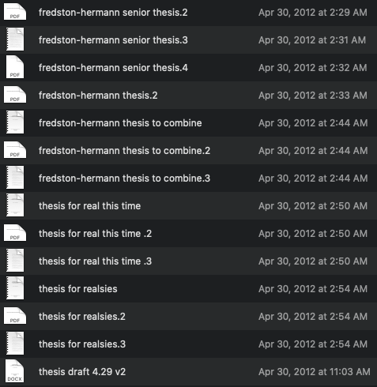

# Git and Github solve this problem

## Git

- Git is a distributed version control system.
- Imagine if Dropbox (saving info on the cloud) and "Track changes" from MS word had a baby.  Git would be that baby.
- But, it's even better because Git is optimized for the things that data scientists spend a lot of time working on (e.g., code)
- There is a learning curve, but I promise you it is worth it.

## Github

- Git and GitHub are two different things.
 - GitHub is an online hosting platform that provides an array of services that are built on the Git system. (There are also other platforms like Bitbucket and GitLab)
 - Just like we don't *need* RStudio to run R code, we don't *need* GitHub to use Git... but it will make our lives a lot easier

https://raw.githack.com/uo-ec607/lectures/master/02-git/02-Git.html

# From software development...

Git and GitHub play a big role in global software development.
- There is a high probability that your fave app., program or package is built using Git-based tools (Rstudio is).

# ... to scientific research

- Git and GitHub help operationalise the ideals of open science and reproducibility
- Journals have increasingly strict requirements regarding reproducibility and data access. GH makes this easy (DOI integration, off-the-shelf licenses, etc )
- I host all my code, data for my research papers, and research protocols on GH.
- GH helps us to collaborate with others and, most importantly, **your future self.**

# Git and Rstudio work well together

We will start with Rprojects to keep organized.

[figure not shown]

# 10 min break and then we will make our first repository together

# Create a GitHub account

Go to [https://github.com/](https://github.com/)

- Click Sign-up and follow directions
- [Advice for your username](https://happygitwithr.com/github-acct.html)

[figure not shown]

# Install git

Follow the directions here from the "Install git" and "Introduce yourself to Git" chapters:
- [https://happygitwithr.com/install-git.html](https://happygitwithr.com/install-git.html)

- This may take a while if you are completely new.  That is OK! Danielle is going to be in a special troubleshooting breakout room to help with all your issues.

- One common issue to look out for... "Support for password authentication was removed!"
- If this happens to you at any time, follow the directions [here](https://happygitwithr.com/https-pat.html)

# First, sign into GitHub and we will create a new repository

- Press the new button

[figure not shown]

# We are going to make a test repo

- Fill in the name and description
- Click "add ReadMe"

[figure not shown]

# Here is your empty repo

[figure not shown]

# "Clone it" and bring it into Rstudio

- Click the green "code" button
- Click the clipboard to copy the link

[figure not shown]

# Open RStudio

- click the carrot on the top right

[figure not shown]

- Click New project

[figure not shown]

# Create a version controlled project

- Click Version control

[figure not shown]

# Create a version controlled project

- Click Git

[figure not shown]

# Create a version controlled project

- Paste the url that you copied from GitHub
- Decide where you want it to live on your computer
- Click Create Project

[figure not shown]

# You have a version-controlled project!

[figure not shown]

# So, now what....

### Most important things to know to version-control your repository

# P
 # A
 # C
 # P

# So, now what....

### Most important things to know to version-control your repository

# Pull
 # Add
 # Commit
 # Push

# So, now what....

### Most important things to know to version-control your repository

# Pull      (please)
 # Add       (always)
 # Commit    (carry)
 # Push      (pizza)

# Most important commands

**Pull** - [git pull] this “downloads” any changes to your repository on github, by your collaborators, or your past self on a different machine. (always do this first! You may have forgotten that you made a change.)

**Add**  - [git add] this stages files. It tells git, "I want to add these to the repository"

**Commit** - [git commit] this “saves” your changes with git (as opposed to ctrl+S which saves them to your local machine – although you should still do that too)

- git commit always requires a message so that you know what changes you made.
  - ex: git commit -a -m "I created a test repo"
  - "-a" means commit all (every change) "-m" means (I am adding a message). What you have in quotes is your message.

**Push**  - [git push] this “uploads” your changes to github.

# Work with git in the terminal

- First, let's create and save a simple script (save it as "testscript.R")

- Now, let's save it to git

- click on the terminal tab (next to console). This allows you to interact directly with your terminal

- type "git pull"  (it should say already up to date because you have not done anything yet)

- type git add testscript.R  (this stages the new script)

- type git commit -a -m "I am adding testscript"

- type git push
  - you may get prompted for your username and password

# What it should look like

Check github and see if it is there!

[figure not shown]

# Let's do the same thing by clicking buttons

- make a new script (testscript2.R)

Find the git tab on the right-hand site

[figure not shown]

# Let's do the same thing by clicking buttons

- check the box next to testscript2.R (this adds it -- once you add a script, you never have to add it again. Only commit new changes)

[figure not shown]

- click commit and add a message

# click commit and add a message

[figure not shown]

- press commit and when it is done hit close and exit out
- next hit "push"
- when it is done close it. You should no longer see "testscript2.R" in the upper right-hand side.
- check github! (Don't forget to refresh the webpage)

# Make some changes!

- Let's make some changes to testscript.R
- add any code you want to it, commit it (with a message), and push it
- click history (the clock on the top) to see what changes were made and by who

# Oh no!

- You notice that your cat walked across the screen totally screwed up your code.  Oh no!

[figure not shown]

- It's ok... you can revert it
- Click the blue wheel and then revert
- Note: commit often (it will only revert back to the last commit you made. This is like pressing the save button. Do it with every major change to your script.)

# Delete this test repository

- click settings and scroll all the way to the bottom ('Danger Zone') and delete repository and follow directions

[figure not shown]

# Next class

- We will learn about proper file structure and how to set-up a transparent script.
- Send me your git username in slack **right now**.
- Don't forget your first quiz is on Thursday at the start of class! Don't be late.

# Thanks!

Slides created via the R package [**xaringan**](https://github.com/yihui/xaringan).

Some slides modified from Allison Horst, Jarret Byrnes